# R Notebook

```r
library(dplyr)
library(readr)

if(getwd() != "C:/School/Ing5/Data Analytics/R-Shiny-Application"){
  print("not in correct directory")
}

data_dir = "data/raw/"
trains = read.csv( "data/raw/french-sncf-trains-regularities/full_trains.csv" )
delays = read_csv2("data/raw/french-sncf-trains-regularities/regularite-mensuelle-tgv-aqst.csv")
```

```
Using ',' as decimal and '.' as grouping mark. Use read_delim() for more control.
```

```r
print(head(trains))
```

|  | year | month | service | departure_station | arrival_station | journey_time_avg | total_num_trips | num_of_canceled_trains | comment_cancellations | num_late_at_departure | avg_delay_late_at_departure | avg_delay_all_departing | comment_delays_at_departure | num_arriving_late | avg_delay_late_on_arrival | avg_delay_all_arriving | comment_delays_on_arrival | delay_cause_external_cause | delay_cause_rail_infrastructure | delay_cause_traffic_management | delay_cause_rolling_stock | delay_cause_station_management | delay_cause_travelers | num_greater_15_min_late | avg_delay_late_greater_15_min | num_greater_30_min_late | num_greater_60_min_late |
| --- | --- | --- | --- | --- | --- | --- | --- | --- | --- | --- | --- | --- | --- | --- | --- | --- | --- | --- | --- | --- | --- | --- | --- | --- | --- | --- | --- |
| 1 | 2017 | 9 | National | PARIS EST | METZ | 85.13378 | 299 | 0 | NA | 15 | 11.55000 | 0.7520067 | NA | 17 | 13.79412 | 0.4198439 | NA | 0.2500000 | 0.0000000 | 0.16666667 | 0.4166667 | 0.16666667 | 0.00000000 | 6 | 24.03333 | 1 | 0 |
| 2 | 2017 | 9 | National | REIMS | PARIS EST | 47.06452 | 218 | 1 | NA | 10 | 14.65333 | 1.2635177 | NA | 23 | 13.57029 | 1.1375576 | NA | 0.2500000 | 0.3750000 | 0.12500000 | 0.1250000 | 0.06250000 | 0.06250000 | 9 | 21.49815 | 1 | 0 |
| 3 | 2017 | 9 | National | PARIS EST | STRASBOURG | 116.23494 | 333 | 1 | NA | 20 | 13.69417 | 1.1392570 | NA | 19 | 21.53246 | 1.5863956 | NA | 0.2142857 | 0.2142857 | 0.07142857 | 0.2857143 | 0.21428571 | 0.00000000 | 14 | 24.69405 | 3 | 0 |
| 4 | 2017 | 9 | National | PARIS LYON | AVIGNON TGV | 161.08958 | 481 | 1 | NA | 36 | 20.98843 | 1.4062153 | NA | 61 | 26.56667 | 4.7885417 | NA | 0.1551724 | 0.1206897 | 0.31034483 | 0.3448276 | 0.03448276 | 0.03448276 | 40 | 34.04750 | 21 | 5 |
| 5 | 2017 | 9 | National | PARIS LYON | BELLEGARDE (AIN) | 164.45263 | 190 | 0 | NA | 16 | 20.96354 | 1.7289474 | NA | 38 | 23.15175 | 6.0088596 | NA | 0.1666667 | 0.2500000 | 0.25000000 | 0.3055556 | 0.00000000 | 0.02777778 | 26 | 28.40128 | 8 | 1 |
| 6 | 2017 | 9 | National | PARIS LYON | BESANCON FRANCHE COMTE TGV | 128.52105 | 191 | 1 | NA | 18 | 19.96389 | 1.8387719 | NA | 18 | 31.58796 | 5.0336842 | NA | 0.1111111 | 0.1111111 | 0.22222222 | 0.5000000 | 0.00000000 | 0.05555556 | 15 | 35.79667 | 8 | 1 |

```r
print(head(delays))
```

| Année | Mois | Service | Gare de départ | Gare d'arrivée | Durée moyenne du trajet (min) | Nombre de circulations prévues | Nombre de trains annulés | Commentaire (facultatif) annulations | Nombre de trains en retard au départ | Retard moyen des trains en retard au départ (min) | Retard moyen de tous les trains au départ (min) | Commentaire (facultatif) retards au départ | Nombre de trains en retard à l'arrivée | Retard moyen des trains en retard à l'arrivée (min) | Retard moyen de tous les trains à l'arrivée (min) | Commentaire (facultatif) retards à l'arrivée | % trains en retard pour causes externes (météo, obstacles, colis suspects, malveillance, mouvements sociaux, etc.) | % trains en retard à cause infrastructure ferroviaire (maintenance, travaux) | % trains en retard à cause gestion trafic (circulation sur ligne ferroviaire, interactions réseaux) | % trains en retard à cause matériel roulant | % trains en retard à cause gestion en gare et réutilisation de matériel | % trains en retard à cause prise en compte voyageurs (affluence, gestions PSH, correspondances) | Nombre trains en retard > 15min | Retard moyen trains en retard > 15min | Nombre trains en retard > 30min | Nombre trains en retard > 60min | Période | Retard pour causes externes | Retard à cause infrastructure ferroviaire | … |
| --- | --- | --- | --- | --- | --- | --- | --- | --- | --- | --- | --- | --- | --- | --- | --- | --- | --- | --- | --- | --- | --- | --- | --- | --- | --- | --- | --- | --- | --- | --- |
| 2017 | 90 | National | PARIS EST | METZ | 851337792642 | 2990 | 0.0 | NA | 15.0 | 11.55 | 0.752006688963 | NA | 170 | 137941176471 | 0.419843924192 | NA | 0.25 | 0.0 | 0.166666666667 | 0.416666666667 | 0.166666666667 | 0.0 | 6.0 | 24.0333333333 | 1.0 | 0.0 | 2017-09 | 25.0 | 0.0 | … |
| 2017 | 90 | National | REIMS | PARIS EST | 47064516129 | 2180 | 1.0 | NA | 10.0 | 14.6533333333 | 1.26351766513 | NA | 230 | 135702898551 | 1.13755760369 | NA | 0.25 | 0.375 | 0.125 | 0.125 | 0.0625 | 0.0625 | 9.0 | 21.4981481481 | 1.0 | 0.0 | 2017-09 | 25.0 | 37.5 | … |
| 2017 | 90 | National | PARIS EST | STRASBOURG | 116234939759 | 3330 | 1.0 | NA | 20.0 | 13.6941666667 | 1.13925702811 | NA | 190 | 215324561404 | 1.58639558233 | NA | 0.214285714286 | 0.214285714286 | 0.0714285714286 | 0.285714285714 | 0.214285714286 | 0.0 | 14.0 | 24.694047619 | 3.0 | 0.0 | 2017-09 | 21.428571428599998 | 21.428571428599998 | … |
| 2017 | 90 | National | PARIS LYON | AVIGNON TGV | 161089583333 | 4810 | 1.0 | NA | 36.0 | 20.9884259259 | 1.40621527778 | NA | 610 | 265666666667 | 4.78854166667 | NA | 0.155172413793 | 0.120689655172 | 0.310344827586 | 0.344827586207 | 0.0344827586207 | 0.0344827586207 | 40.0 | 34.0475 | 21.0 | 5.0 | 2017-09 | 15.517241379300001 | 12.0689655172 | … |
| 2017 | 90 | National | PARIS LYON | BELLEGARDE (AIN) | 164452631579 | 1900 | 0.0 | NA | 16.0 | 20.9635416667 | 1.72894736842 | NA | 380 | 23151754386 | 6.00885964912 | NA | 0.166666666667 | 0.25 | 0.25 | 0.305555555556 | 0.0 | 0.0277777777778 | 26.0 | 28.4012820513 | 8.0 | 1.0 | 2017-09 | 16.6666666667 | 25.0 | … |
| 2017 | 90 | National | PARIS LYON | BESANCON FRANCHE COMTE TGV | 128521052632 | 1910 | 1.0 | NA | 18.0 | 19.9638888889 | 1.83877192982 | NA | 180 | 31587962963 | 5.03368421053 | NA | 0.111111111111 | 0.111111111111 | 0.222222222222 | 0.5 | 0.0 | 0.0555555555556 | 15.0 | 35.7966666667 | 8.0 | 1.0 | 2017-09 | 11.1111111111 | 11.1111111111 | … |

```r
NA
NA
NA
NA
NA
NA
```

Data preprocessing:

Show the aggregated values per year (2015, 2016, 2017, 2018) of 1 The total number of trains that have been carried out 2 The total number of delayed trains at departure 3 The total number of delayed trains at arrival 4 The average number of delayed trains at departure 5 The average number of delayed trains at arrival 6 The total average departure delay time of all trains 7 The total average arrival delay time of all trains 8 The average departure delay time of delayed trains 9 The average arrival delay time of delayed trains 10 The total number of cancelled trains 11 The percentage (proportion) of cancelled trains 12 The percentage (proportion) of delay causes

```r
trains = data.frame(trains)
delays = data.frame(delays)

train_agg = data.frame()

#1-3
total_trains = aggregate(total_num_trips ~ year, trains, sum)
total_depart_delays = aggregate(num_late_at_departure ~ year, trains, sum)
total_arrival_delays = aggregate(num_arriving_late ~ year, trains, sum)

#3-4
avg_depart_delays = aggregate(num_late_at_departure ~ year, trains, mean)
avg_arrival_delays = aggregate(num_arriving_late ~ year, trains, mean)

#6-7
total_avg_depart_delay = aggregate(avg_delay_late_on_arrival ~ year, trains, sum)
total_avg_arrival_delay = aggregate(avg_delay_late_at_departure ~ year, trains, sum)

#8-9
avg_depart_delay = aggregate(avg_delay_late_on_arrival ~ year, trains, mean)
avg_arrival_delay = aggregate(avg_delay_late_at_departure ~ year, trains, mean)

#10-11
total_train_cancelled = aggregate(num_of_canceled_trains ~ year, trains, sum)
percent_cancelled_trains = data.frame(year= c(2015,2016,2017,2018), percent_cancelled =total_trains$total_num_trips/total_train_cancelled$num_of_canceled_trains)



#percent_delays_causes = trains %>% group_by(year)
#                                   %>%
#aggregate(list(trains$delay_cause_external_cause,trains$delay_cause_rail_infrastructure,trains$delay_cause_traffic_m#anagement,trains$delay_cause_rolling_stock,trains$delay_cause_station_management,trains$delay_cause_travelers), by #=list( trains$year) , mean)
#
#head(percent_delays_causes)


percent_delays_causes = trains %>% group_by(year) %>% summarise(external = mean(delay_cause_external_cause, na.rm=TRUE),infrastructure = mean(delay_cause_rail_infrastructure, na.rm=TRUE), traffic_management=mean(delay_cause_traffic_management, na.rm = TRUE), rolling_stock = mean(delay_cause_rolling_stock, na.rm=TRUE), station = mean(delay_cause_station_management, na.rm=TRUE), travelers = mean(delay_cause_travelers, na.rm=TRUE), )

print(percent_delays_causes$infrastructure)
```

```
[1] 0.2613755 0.2646565 0.2466274 0.2355610
```

```r
#save to csv

#make big data frame with all calculated aggregations
train_year_agg  = data.frame(cbind(percent_delays_causes$year,
                                   total_trains$total_num_trips,
                                   total_depart_delays$num_late_at_departure,
                                   total_arrival_delays$num_arriving_late,
                                   avg_depart_delays$num_late_at_departure,
                                   avg_arrival_delays$num_arriving_late,
                                   total_avg_depart_delay$avg_delay_late_on_arrival,
                                   total_avg_arrival_delay$avg_delay_late_at_departure,
                                   avg_depart_delay$avg_delay_late_on_arrival,
                                   avg_arrival_delay$avg_delay_late_at_departure,
                                   total_train_cancelled$num_of_canceled_trains,
                                   percent_cancelled_trains$percent_cancelled,
                                   percent_delays_causes$external,
                                   percent_delays_causes$infrastructure,
                                   percent_delays_causes$traffic_management,
                                   percent_delays_causes$rolling_stock,
                                   percent_delays_causes$station,
                                   percent_delays_causes$travelers
                                   ))
colnames(train_year_agg) = c("year","total_trips","num_departure_delays","num_arrival_delays",
                             "avg_num_departure_delays","avg_num_arrival_delays",
                             "total_depart_delay","total_arrival_delay",
                             "avg_depart_delay", "avg_arrival_delay",
                             "num_trains_cancelled","percent_cancelled",
                             "delay_external", "delay_infrastructure", "delay_traffic",
                             "delay_stock","delay_station","delay_travelers")
print(train_year_agg)
```

| year | total_trips | num_departure_delays | num_arrival_delays | avg_num_departure_delays | avg_num_arrival_delays | total_depart_delay | total_arrival_delay | avg_depart_delay | avg_arrival_delay | num_trains_cancelled | percent_cancelled | delay_external | delay_infrastructure | delay_traffic | delay_stock | delay_station | delay_travelers |
| --- | --- | --- | --- | --- | --- | --- | --- | --- | --- | --- | --- | --- | --- | --- | --- | --- | --- |
| 2015 | 388255 | 36001 | 41781 | 26.78646 | 31.11020 | 44351.01 | 23915.29 | 33.02383 | 17.79412 | 927 | 418.82956 | 0.3027807 | 0.2613755 | 0.1564827 | 0.1492054 | 0.08242864 | 0.04365385 |
| 2016 | 373820 | 38556 | 42631 | 28.68750 | 31.79045 | 44316.45 | 25824.34 | 33.04732 | 19.21454 | 6219 | 60.10934 | 0.3003792 | 0.2646565 | 0.1651233 | 0.1356904 | 0.09354077 | 0.04060979 |
| 2017 | 391754 | 49554 | 59728 | 36.87054 | 44.44048 | 41124.28 | 24389.06 | 30.59842 | 18.14662 | 3828 | 102.33908 | 0.2536852 | 0.2466274 | 0.2051340 | 0.2107545 | 0.05140042 | 0.03239840 |
| 2018 | 381371 | 102986 | 63238 | 72.01818 | 44.37754 | 47181.16 | 17681.51 | 33.10959 | 12.36470 | 31287 | 12.18944 | 0.2569181 | 0.2355610 | 0.2040348 | 0.2165625 | 0.05400132 | 0.03292232 |

```r
#write_csv(train_year_agg,path="data")
write.csv(train_year_agg, file = "data/analytics/train_year.csv", row.names=FALSE)
```

Same aggregations but by train station instead

```r
trains = data.frame(trains)
delays = data.frame(delays)

train_agg = data.frame()

#1-3
total_trains = aggregate(total_num_trips ~ departure_station, trains, sum)
total_depart_delays = aggregate(num_late_at_departure ~ departure_station, trains, sum)
total_arrival_delays = aggregate(num_arriving_late ~ departure_station, trains, sum)

#3-4
avg_depart_delays = aggregate(num_late_at_departure ~ departure_station, trains, mean)
avg_arrival_delays = aggregate(num_arriving_late ~ departure_station, trains, mean)

#6-7
total_avg_depart_delay = aggregate(avg_delay_late_on_arrival ~ departure_station, trains, sum)
total_avg_arrival_delay = aggregate(avg_delay_late_at_departure ~ departure_station, trains, sum)

#8-9
avg_depart_delay = aggregate(avg_delay_late_on_arrival ~ departure_station, trains, mean)
avg_arrival_delay = aggregate(avg_delay_late_at_departure ~ departure_station, trains, mean)

#10-11
total_train_cancelled = aggregate(num_of_canceled_trains ~ departure_station, trains, sum)
percent_cancelled_trains = data.frame(departure_station=total_train_cancelled$departure_station , percent_cancelled =total_trains$total_num_trips/total_train_cancelled$num_of_canceled_trains)


percent_delays_causes = trains %>% group_by(departure_station) %>% summarise(
                                            external =mean(delay_cause_external_cause,na.rm=TRUE),
                                            infrastructure = mean(delay_cause_rail_infrastructure, na.rm=TRUE),
                                            traffic_management=mean(delay_cause_traffic_management, na.rm = TRUE),
                                            rolling_stock = mean(delay_cause_rolling_stock, na.rm=TRUE),
                                            station = mean(delay_cause_station_management, na.rm=TRUE),
                                            travelers = mean(delay_cause_travelers, na.rm=TRUE), )



#save to csv

#make big data frame with all calculated aggregations
train_departure_station_agg  = data.frame(total_trains$departure_station,
                              cbind(
                                    total_trains$total_num_trips,
                                   total_depart_delays$num_late_at_departure,
                                   total_arrival_delays$num_arriving_late,
                                   avg_depart_delays$num_late_at_departure,
                                   avg_arrival_delays$num_arriving_late,
                                   total_avg_depart_delay$avg_delay_late_on_arrival,
                                   total_avg_arrival_delay$avg_delay_late_at_departure,
                                   avg_depart_delay$avg_delay_late_on_arrival,
                                   avg_arrival_delay$avg_delay_late_at_departure,
                                   total_train_cancelled$num_of_canceled_trains,
                                   percent_cancelled_trains$percent_cancelled,
                                   percent_delays_causes$external,
                                   percent_delays_causes$infrastructure,
                                   percent_delays_causes$traffic_management,
                                   percent_delays_causes$rolling_stock,
                                   percent_delays_causes$station,
                                   percent_delays_causes$travelers
                                   ))

colnames(train_departure_station_agg) = c("departure_station","total_trips","num_departure_delays","num_arrival_delays",
                             "avg_num_departure_delays","avg_num_arrival_delays",
                             "total_depart_delay","total_arrival_delay",
                             "avg_depart_delay", "avg_arrival_delay",
                             "num_trains_cancelled","percent_cancelled",
                             "delay_external", "delay_infrastructure", "delay_traffic",
                             "delay_stock","delay_station","delay_travelers")


print(train_departure_station_agg)
```

| departure_station | total_trips | num_departure_delays | num_arrival_delays | avg_num_departure_delays | avg_num_arrival_delays | total_depart_delay | total_arrival_delay | avg_depart_delay | avg_arrival_delay | num_trains_cancelled | percent_cancelled | delay_external | delay_infrastructure | delay_traffic | delay_stock | delay_station | delay_travelers |
| --- | --- | --- | --- | --- | --- | --- | --- | --- | --- | --- | --- | --- | --- | --- | --- | --- | --- |
| AIX EN PROVENCE TGV | 19391 | 3658 | 2020 | 77.829787 | 42.978723 | 1879.7468 | 781.16334 | 39.99461 | 16.620497 | 299 | 64.852843 | 0.3499465 | 0.2040759 | 0.14124803 | 0.19269482 | 0.07569889 | 0.03633586 |
| ANGERS SAINT LAUD | 20315 | 3585 | 2733 | 76.276596 | 58.148936 | 1297.5766 | 706.20498 | 27.60801 | 15.025638 | 500 | 40.630000 | 0.2785309 | 0.3386001 | 0.15455943 | 0.12817125 | 0.05826647 | 0.04187184 |
| ANGOULEME | 14590 | 3756 | 2251 | 79.914894 | 47.893617 | 1456.1247 | 681.37064 | 30.98138 | 14.497248 | 460 | 31.717391 | 0.2574050 | 0.3479567 | 0.17980429 | 0.10516669 | 0.05687345 | 0.05279388 |
| ANNECY | 8534 | 335 | 1279 | 7.127660 | 27.212766 | 1728.5243 | 778.67336 | 36.77711 | 16.567518 | 276 | 30.920290 | 0.2654875 | 0.2638801 | 0.24415182 | 0.15203564 | 0.03897702 | 0.03546790 |
| ARRAS | 15225 | 2328 | 2555 | 49.531915 | 54.361702 | 822.6105 | 654.10461 | 17.50235 | 13.917119 | 574 | 26.524390 | 0.2054379 | 0.2792707 | 0.28115367 | 0.11520242 | 0.09155781 | 0.02737748 |
| AVIGNON TGV | 25943 | 6804 | 4233 | 144.765957 | 90.063830 | 1615.7323 | 841.45349 | 34.37728 | 17.903266 | 504 | 51.474206 | 0.3167375 | 0.2334810 | 0.17838194 | 0.16852179 | 0.06070584 | 0.04217194 |
| BARCELONA | 789 | 282 | 172 | 25.636364 | 15.636364 | 558.9333 | 51.99458 | 50.81212 | 4.726780 | 45 | 17.533333 | 0.4180500 | 0.2787301 | 0.08463122 | 0.21858868 | 0.00000000 | 0.00000000 |
| BELLEGARDE (AIN) | 10849 | 2205 | 1424 | 46.914894 | 30.297872 | 1475.1028 | 548.02051 | 31.38517 | 11.660011 | 260 | 41.726923 | 0.2925475 | 0.2652475 | 0.24877146 | 0.10591546 | 0.04480815 | 0.04270996 |
| BESANCON FRANCHE COMTE TGV | 9328 | 643 | 624 | 13.680851 | 13.276596 | 1456.6010 | 723.39136 | 30.99151 | 15.391306 | 242 | 38.545455 | 0.2498802 | 0.2440782 | 0.20254992 | 0.16767154 | 0.08218267 | 0.05363752 |
| BORDEAUX ST JEAN | 34739 | 7323 | 5166 | 106.130435 | 74.869565 | 2752.0750 | 1067.66449 | 39.88514 | 15.473398 | 1368 | 25.394006 | 0.2726483 | 0.2943614 | 0.22105796 | 0.13775871 | 0.04098372 | 0.03318984 |

[output cut: 49 more lines]

```r
write.csv(train_departure_station_agg, file = "data/analytics/train_station.csv", row.names=FALSE)
```

# preprocessing of flights data

next, we move onto the flights dataset which contains quite a bit of data

```r
flights = read_csv("data/raw/flights.csv")
airlines = read_csv("data/raw/airlines.csv")
airports = read_csv("data/raw/airports.csv")
print(head(flights))
```

| YEAR | MONTH | DAY | DAY_OF_WEEK | AIRLINE | FLIGHT_NUMBER | TAIL_NUMBER | ORIGIN_AIRPORT | DESTINATION_AIRPORT | SCHEDULED_DEPARTURE | DEPARTURE_TIME | DEPARTURE_DELAY | TAXI_OUT | WHEELS_OFF | SCHEDULED_TIME | ELAPSED_TIME | AIR_TIME | DISTANCE | WHEELS_ON | TAXI_IN | SCHEDULED_ARRIVAL | ARRIVAL_TIME | ARRIVAL_DELAY | DIVERTED | CANCELLED | CANCELLATION_REASON | AIR_SYSTEM_DELAY | SECURITY_DELAY | AIRLINE_DELAY | LATE_AIRCRAFT_DELAY | … |
| --- | --- | --- | --- | --- | --- | --- | --- | --- | --- | --- | --- | --- | --- | --- | --- | --- | --- | --- | --- | --- | --- | --- | --- | --- | --- | --- | --- | --- | --- | --- |
| 2015 | 1 | 1 | 4 | AS | 98 | N407AS | ANC | SEA | 0005 | 2354 | -11 | 21 | 0015 | 205 | 194 | 169 | 1448 | 0404 | 4 | 0430 | 0408 | -22 | 0 | 0 | NA | NA | NA | NA | NA | … |
| 2015 | 1 | 1 | 4 | AA | 2336 | N3KUAA | LAX | PBI | 0010 | 0002 | -8 | 12 | 0014 | 280 | 279 | 263 | 2330 | 0737 | 4 | 0750 | 0741 | -9 | 0 | 0 | NA | NA | NA | NA | NA | … |
| 2015 | 1 | 1 | 4 | US | 840 | N171US | SFO | CLT | 0020 | 0018 | -2 | 16 | 0034 | 286 | 293 | 266 | 2296 | 0800 | 11 | 0806 | 0811 | 5 | 0 | 0 | NA | NA | NA | NA | NA | … |
| 2015 | 1 | 1 | 4 | AA | 258 | N3HYAA | LAX | MIA | 0020 | 0015 | -5 | 15 | 0030 | 285 | 281 | 258 | 2342 | 0748 | 8 | 0805 | 0756 | -9 | 0 | 0 | NA | NA | NA | NA | NA | … |
| 2015 | 1 | 1 | 4 | AS | 135 | N527AS | SEA | ANC | 0025 | 0024 | -1 | 11 | 0035 | 235 | 215 | 199 | 1448 | 0254 | 5 | 0320 | 0259 | -21 | 0 | 0 | NA | NA | NA | NA | NA | … |
| 2015 | 1 | 1 | 4 | DL | 806 | N3730B | SFO | MSP | 0025 | 0020 | -5 | 18 | 0038 | 217 | 230 | 206 | 1589 | 0604 | 6 | 0602 | 0610 | 8 | 0 | 0 | NA | NA | NA | NA | NA | … |

```r
print(head(airlines))
```

| IATA_CODE | AIRLINE |
| --- | --- |
| UA | United Air Lines Inc. |
| AA | American Airlines Inc. |
| US | US Airways Inc. |
| F9 | Frontier Airlines Inc. |
| B6 | JetBlue Airways |
| OO | Skywest Airlines Inc. |

```r
print(head(airports))
```

| IATA_CODE | AIRPORT | CITY | STATE | COUNTRY | LATITUDE | LONGITUDE |
| --- | --- | --- | --- | --- | --- | --- |
| ABE | Lehigh Valley International Airport | Allentown | PA | USA | 40.65236 | -75.44040 |
| ABI | Abilene Regional Airport | Abilene | TX | USA | 32.41132 | -99.68190 |
| ABQ | Albuquerque International Sunport | Albuquerque | NM | USA | 35.04022 | -106.60919 |
| ABR | Aberdeen Regional Airport | Aberdeen | SD | USA | 45.44906 | -98.42183 |
| ABY | Southwest Georgia Regional Airport | Albany | GA | USA | 31.53552 | -84.19447 |
| ACK | Nantucket Memorial Airport | Nantucket | MA | USA | 41.25305 | -70.06018 |

## aggregations by airline

1. The total number of flights
2. The total number of delayed flights
3. The average flight duration
4. The average flight distance
5. The total distance covered by all airline flights
6. The average departure delay
7. The average arrival delay

```r
# 1-7
total_flights = flights %>% group_by(AIRLINE) %>% tally(name="flight_count")
total_delayed_flights = flights %>% group_by(AIRLINE) %>% filter(DEPARTURE_DELAY > 0) %>% tally(name="delay_count")
avg_flight_time = flights %>% group_by(AIRLINE) %>% summarise(duration = mean(ELAPSED_TIME,na.rm=TRUE))
avg_flight_distance = flights %>% group_by(AIRLINE) %>% summarise(distance = mean(DISTANCE, na.rm=TRUE))
total_flight_distance = flights %>% group_by(AIRLINE) %>% summarise(distance = sum(DISTANCE) )
avg_depart_delay = flights %>% group_by(AIRLINE) %>% summarise(delay = mean(DEPARTURE_DELAY,na.rm=TRUE))
avg_arrival_delay = flights %>% group_by(AIRLINE) %>% summarise(delay = mean(ARRIVAL_DELAY,na.rm=TRUE))

flights_airline_agg = data.frame(total_flights$AIRLINE,
                                 cbind(total_flights$flight_count,
                                       total_delayed_flights$delay_count,
                                       avg_flight_time$duration,
                                       avg_flight_distance$distance,
                                       total_flight_distance$distance,
                                       avg_depart_delay$delay,
                                       avg_arrival_delay$delay))

colnames(flights_airline_agg) = c("airline",
                                  "flight_count",
                                  "delay_count",
                                  "avg_duration",
                                  "avg_distance",
                                  "total_distance",
                                  "avg_depart_delay",
                                  "avg_arrival_delay")

print(flights_airline_agg)
```

| airline | flight_count | delay_count | avg_duration | avg_distance | total_distance | avg_depart_delay | avg_arrival_delay |
| --- | --- | --- | --- | --- | --- | --- | --- |
| AA | 725984 | 245904 | 166.43328 | 1041.3392 | 755995614 | 8.9008563 | 3.4513721 |
| AS | 172521 | 43566 | 179.33979 | 1197.4181 | 206579765 | 1.7858007 | -0.9765631 |
| B6 | 267048 | 102061 | 167.83886 | 1062.1752 | 283651757 | 11.5143527 | 6.6778608 |
| DL | 875881 | 282463 | 140.47196 | 853.6218 | 747671138 | 7.3692542 | 0.1867536 |
| EV | 571977 | 169897 | 97.12425 | 462.2517 | 264397363 | 8.7159345 | 6.5853787 |
| F9 | 90836 | 34893 | 155.05668 | 967.2149 | 87857929 | 13.3508583 | 12.5047064 |
| HA | 76272 | 20146 | 102.67227 | 632.5918 | 48249045 | 0.4857132 | 2.0230928 |
| MQ | 294632 | 93726 | 92.59352 | 422.3154 | 124427633 | 10.1251882 | 6.4578735 |
| NK | 117379 | 52089 | 156.50360 | 985.2671 | 115649669 | 15.9447659 | 14.4717995 |
| OO | 588353 | 171572 | 100.72456 | 496.7722 | 292277393 | 7.8011038 | 5.8456522 |

[output cut: 4 more lines]

```r
write.csv(flights_airline_agg, file = "data/analytics/flights_airline.csv", row.names=FALSE)
```

same aggragations but groupping by airport instead of airline

```r
# 1-7
total_flights = flights %>% group_by(ORIGIN_AIRPORT) %>% tally(name="flight_count")
total_delayed_flights = flights %>% group_by(ORIGIN_AIRPORT) %>% filter(DEPARTURE_DELAY > 0) %>% tally(name="delay_count")
avg_flight_time = flights %>% group_by(ORIGIN_AIRPORT) %>% summarise(duration = mean(ELAPSED_TIME,na.rm=TRUE))
avg_flight_distance = flights %>% group_by(ORIGIN_AIRPORT) %>% summarise(distance = mean(DISTANCE, na.rm=TRUE))
total_flight_distance = flights %>% group_by(ORIGIN_AIRPORT) %>% summarise(distance = sum(DISTANCE) )
avg_depart_delay = flights %>% group_by(ORIGIN_AIRPORT) %>% summarise(delay = mean(DEPARTURE_DELAY,na.rm=TRUE))
avg_arrival_delay = flights %>% group_by(ORIGIN_AIRPORT) %>% summarise(delay = mean(ARRIVAL_DELAY,na.rm=TRUE))


flights_aiport_agg = data.frame(total_flights$ORIGIN_AIRPORT,
                                 cbind(total_flights$flight_count,
                                       total_delayed_flights$delay_count,
                                       avg_flight_time$duration,
                                       avg_flight_distance$distance,
                                       total_flight_distance$distance,
                                       avg_depart_delay$delay,
                                       avg_arrival_delay$delay))
```

```
number of rows of result is not a multiple of vector length (arg 2)
```

```r
colnames(flights_aiport_agg) = c("airport",
                                  "flight_count",
                                  "delay_count",
                                  "avg_duration",
                                  "avg_distance",
                                  "total_distance",
                                  "avg_depart_delay",
                                  "avg_arrival_delay")

print(flights_aiport_agg)
```

| airport | flight_count | delay_count | avg_duration | avg_distance | total_distance | avg_depart_delay | avg_arrival_delay |
| --- | --- | --- | --- | --- | --- | --- | --- |
| 10135 | 239 | 69 | 118.20921 | 596.4477 | 142551 | 9.37238494 | 6.56485356 |
| 10136 | 201 | 39 | 53.46354 | 158.0000 | 31758 | 4.06185567 | -6.00520833 |
| 10140 | 1816 | 687 | 117.41884 | 729.9163 | 1325528 | 5.95966851 | 0.70470914 |
| 10141 | 71 | 16 | 68.14286 | 257.0000 | 18247 | 1.51428571 | 0.67142857 |
| 10146 | 87 | 20 | 56.83721 | 145.0000 | 12615 | 8.66666667 | 10.87209302 |
| 10154 | 28 | 13 | 63.67857 | 172.0000 | 4816 | 22.85714286 | 25.53571429 |
| 10155 | 148 | 14 | 47.57447 | 89.0000 | 13172 | -4.13380282 | -12.57446809 |
| 10157 | 122 | 37 | 66.07563 | 250.0000 | 30500 | 12.23529412 | 9.25210084 |
| 10158 | 248 | 49 | 134.26939 | 837.2500 | 207638 | -0.07692308 | -4.75510204 |
| 10165 | 9 | 5 | 166.00000 | 1192.0000 | 10728 | 17.55555556 | 19.55555556 |

[output cut: 618 more lines]

```r
write.csv(flights_aiport_agg, file = "data/analytics/flights_airport.csv", row.names=FALSE)
```

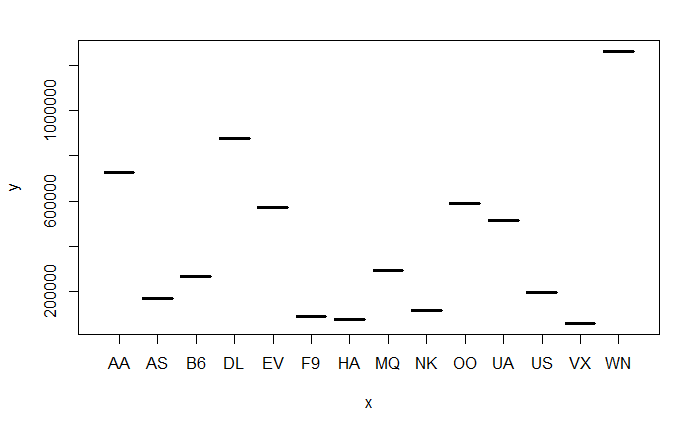

```r
library(shiny)
library(readr)

#load aggregated datasets

flights_airport_agg = read_csv("data/analytics/flights_airport.csv")
flights_airline_agg = read_csv("data/analytics/flights_airline.csv")
train_year_agg = read_csv("data/analytics/train_year.csv")
train_station_agg = read_csv("data/analytics/train_station.csv")
plot(factor(flights_airline_agg$airline),flights_airline_agg$flight_count)
```

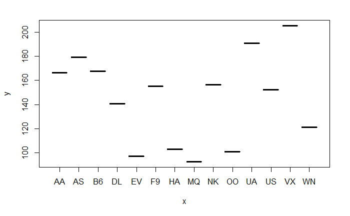

```r
plot(factor(flights_airline_agg$airline),flights_airline_agg$avg_duration)
```

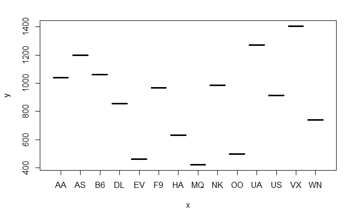

```r
plot(factor(flights_airline_agg$airline),flights_airline_agg$avg_distance)
```

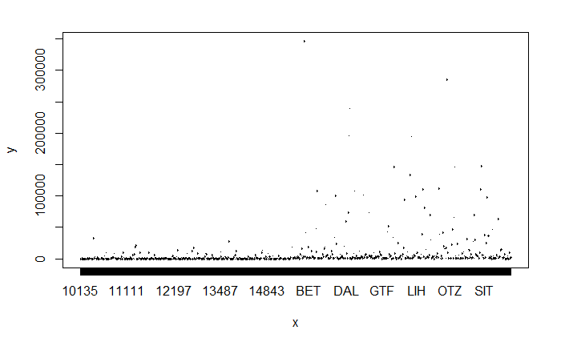

```r
plot(factor(flights_airport_agg$airport),flights_airport_agg$flight_count)
```

```r
NA
NA
NA
```

```r
print(flights_airport_agg["airport"])
```

| airport |
| --- |
| 10135 |
| 10136 |
| 10140 |
| 10141 |
| 10146 |
| 10154 |
| 10155 |
| 10157 |
| 10158 |
| 10165 |

[output cut: 618 more lines]

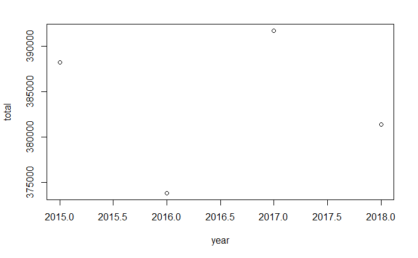

```r
plot(train_year_agg[["year"]],train_year_agg[["total_trips"]], xlab="year", ylab="total")
```

```r
NA
NA
```

```r
train_year_agg[,"total_trips"]
```

| total_trips |
| --- |
| 388255 |
| 373820 |
| 391754 |
| 381371 |

```r
print(as.vector(train_year_agg$year))
```

```
[1] 2015 2016 2017 2018
```

```r
print(typeof(as.vector(train_year_agg[,"total_trips"])))
```

```
[1] "list"
```

```r
pie(train_year_agg[0,"year"],cbind(train_year_agg[0,"delay_external"],train_year_agg[0,"delay_infrastructure"]) )
```

```
Error in pie(train_year_agg[0, "year"], cbind(train_year_agg[0, "delay_external"],  :
  'x' values must be positive.
```

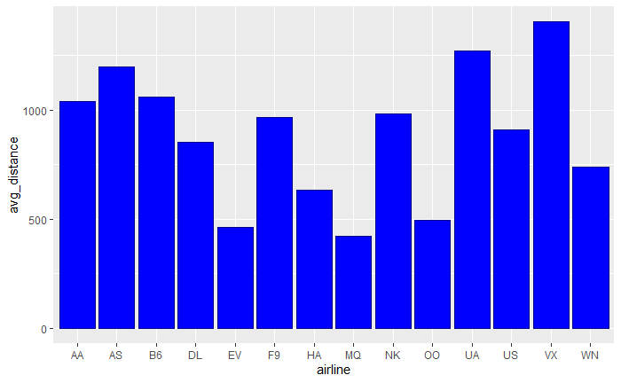

```r
library(ggplot2)



ggplot(data.frame(flights_airline_agg), aes(x=airline, y=avg_distance)) + geom_bar(stat="identity", color='darkblue', fill="blue")
```

```r
NA
NA
```

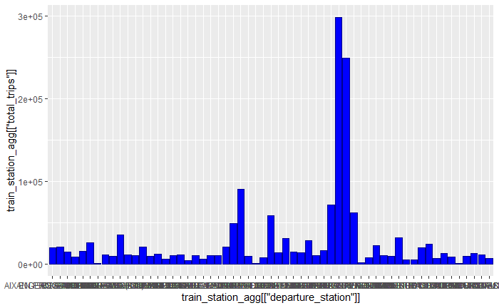

```r
ggplot(data.frame(train_station_agg), aes(x=train_station_agg[["departure_station"]], y=train_station_agg[["total_trips"]] ) ) + geom_bar(stat="identity", color='darkblue', fill="blue")
```